# Day3_hyperspectral_data_excercise

## Exercise on hyperspectral data uncertainty: NDVI calculation and comparison of different trajectories

Geraldine Klarenberg  
with Stephen Escarzaga  
gklarenberg@ufl.edu  
11 July 2018

For this exercise, we use hyperspectral images of the same site, flown with different trajectories. We use a location where we know the data overlaps.

First install the required packages.

```python
import h5py
import csv
import numpy as np
import os
import gdal
import matplotlib.pyplot as plt
import sys
from math import floor
import time
import warnings
warnings.filterwarnings('ignore')
```

Load the function to convert the hdf5 file to an array.

```python
def h5refl2array(h5_filename):
    hdf5_file = h5py.File(h5_filename,'r')

    #Get the site name
    file_attrs_string = str(list(hdf5_file.items()))
    file_attrs_string_split = file_attrs_string.split("'")
    sitename = file_attrs_string_split[1]
    refl = hdf5_file[sitename]['Reflectance']
    reflArray = refl['Reflectance_Data']
    refl_shape = reflArray.shape
    wavelengths = refl['Metadata']['Spectral_Data']['Wavelength']
    #Create dictionary containing relevant metadata information
    metadata = {}
    metadata['shape'] = reflArray.shape
    metadata['mapInfo'] = refl['Metadata']['Coordinate_System']['Map_Info']
    #Extract no data value & set no data value to NaN\n",
    metadata['scaleFactor'] = float(reflArray.attrs['Scale_Factor'])
    metadata['noDataVal'] = float(reflArray.attrs['Data_Ignore_Value'])
    metadata['bad_band_window1'] = (refl.attrs['Band_Window_1_Nanometers'])
    metadata['bad_band_window2'] = (refl.attrs['Band_Window_2_Nanometers'])
    metadata['projection'] = refl['Metadata']['Coordinate_System']['Proj4'].value
    metadata['EPSG'] = int(refl['Metadata']['Coordinate_System']['EPSG Code'].value)
    mapInfo = refl['Metadata']['Coordinate_System']['Map_Info'].value
    mapInfo_string = str(mapInfo); #print('Map Info:',mapInfo_string)\n",
    mapInfo_split = mapInfo_string.split(",")
    #Extract the resolution & convert to floating decimal number
    metadata['res'] = {}
    metadata['res']['pixelWidth'] = mapInfo_split[5]
    metadata['res']['pixelHeight'] = mapInfo_split[6]
    #Extract the upper left-hand corner coordinates from mapInfo\n",
    xMin = float(mapInfo_split[3]) #convert from string to floating point number\n",
    yMax = float(mapInfo_split[4])
    #Calculate the xMax and yMin values from the dimensions\n",
    xMax = xMin + (refl_shape[1]*float(metadata['res']['pixelWidth'])) #xMax = left edge + (# of columns * resolution)\n",
    yMin = yMax - (refl_shape[0]*float(metadata['res']['pixelHeight'])) #yMin = top edge - (# of rows * resolution)\n",
    metadata['extent'] = (xMin,xMax,yMin,yMax),
    metadata['ext_dict'] = {}
    metadata['ext_dict']['xMin'] = xMin
    metadata['ext_dict']['xMax'] = xMax
    metadata['ext_dict']['yMin'] = yMin
    metadata['ext_dict']['yMax'] = yMax
    hdf5_file.close
    return reflArray, metadata, wavelengths

print('Starting BRDF Analysis')
```

```
Starting BRDF Analysis
```

We checked in advance which box (coords) we need for the analysis. Define it.

```python
BRDF_rectangle = np.array([[740315,3982265],[740928,3981839]], dtype=np.float)
```

```python
x_coord = 740600
y_coord = 3982000
```

```python
if BRDF_rectangle[0,0] <= BRDF_rectangle[1,0] and BRDF_rectangle[1,1] < y_coord <= BRDF_rectangle[0,1]:
    print('Point in bounding box')
    # usually we'd use that subtraction format that we used earlier. But Tristan knows the origin is at that rectangle
    y_index = floor(x_coord - BRDF_rectangle[0,0])
    x_index = floor(BRDF_rectangle[0,1] - y_coord)
else:
    print('Point not in bounding area, exiting')
    raise Exception('exit')
```

```
Point in bounding box
```

Now we take all files that we have (batch processing) and calculate the NDVI in the target box for each and add each to a plot. This happens inside a loop.

```python
h5_directory = "F07A/"
all_files = os.listdir(h5_directory)
h5_files = [i for i in all_files if i.endswith('.h5')]
```

```
Working onNEON_D07_F07A_DP1_20160611_162007_reflectance_modify.h5
NDVI is: 0.861
Working onNEON_D07_F07A_DP1_20160611_172430_reflectance_modify.h5
NDVI is: 0.89
Working onNEON_D07_F07A_DP1_20160611_170118_reflectance_modify.h5
NDVI is: 0.86
Working onNEON_D07_F07A_DP1_20160611_164259_reflectance_modify.h5
Working onNEON_D07_F07A_DP1_20160611_171403_reflectance_modify.h5
NDVI is: 0.865
Working onNEON_D07_F07A_DP1_20160611_160846_reflectance_modify.h5
NDVI is: 0.842
Working onNEON_D07_F07A_DP1_20160611_170922_reflectance_modify.h5
NDVI is: 0.862
Working onNEON_D07_F07A_DP1_20160611_162514_reflectance_modify.h5
NDVI is: 0.882
Working onNEON_D07_F07A_DP1_20160611_160444_reflectance_modify.h5
NDVI is: 0.907
Working onNEON_D07_F07A_DP1_20160611_170538_reflectance_modify.h5
Working onNEON_D07_F07A_DP1_20160611_171852_reflectance_modify.h5
NDVI is: 0.856
Working onNEON_D07_F07A_DP1_20160611_163945_reflectance_modify.h5
NDVI is: 0.876
Working onNEON_D07_F07A_DP1_20160611_163424_reflectance_modify.h5
NDVI is: 0.863
Working onNEON_D07_F07A_DP1_20160611_165240_reflectance_modify.h5
NDVI is: 0.871
Working onNEON_D07_F07A_DP1_20160611_161228_reflectance_modify.h5
NDVI is: 0.885
Working onNEON_D07_F07A_DP1_20160611_162951_reflectance_modify.h5
NDVI is: 0.887
Working onNEON_D07_F07A_DP1_20160611_161532_reflectance_modify.h5
Working onNEON_D07_F07A_DP1_20160611_165711_reflectance_modify.h5
NDVI is: 0.845
Working onNEON_D07_F07A_DP1_20160611_164809_reflectance_modify.h5
NDVI is: 0.866
```

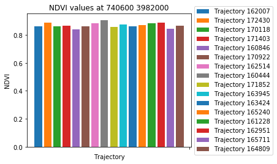

```python
fig = plt.figure()
ax = plt.subplot(111)

for file in h5_files:
    print('Working on' + file)
    [reflArray, metadata, wavelengths] = h5refl2array(h5_directory+file)

    # select the red and NIR bands and calculate NDVI
    vis_reflectance = reflArray[y_index, x_index, 57]
    if vis_reflectance == metadata['noDataVal']:  # if no data, everything would be no data
        continue
    nir_reflectance = reflArray[y_index, x_index, 89]

    ndvi = (nir_reflectance-vis_reflectance)/(nir_reflectance+vis_reflectance)
    ndvi = round(ndvi,3)
    print('NDVI is: '+ str(ndvi))

    filename_split = (file).split("_")
    ax.bar(file, ndvi, label = 'Trajectory '+filename_split[5])

box = ax.get_position()
ax.set_position([box.x0, box.y0, box.width*0.8, box.height])
ax.legend(loc='center left', bbox_to_anchor=(1,0.5))
plt.title('NDVI values at ' + str(x_coord) + ' ' + str(y_coord))
plt.xticks("")
plt.xlabel('Trajectory')
plt.ylabel('NDVI')
plt.show()
```

```python
[reflArray1, metadata1, wavelengths1] = h5refl2array('F07A/NEON_D07_F07A_DP1_20160611_165711_reflectance_modify.h5')
```

```python
[reflArray2, metadata2, wavelengths2] = h5refl2array('F07A/NEON_D07_F07A_DP1_20160611_160444_reflectance_modify.h5')
```

Load the function to plot reflectance.

```python
def plot_aop_refl(band_array,refl_extent,colorlimit=(0,1),ax=plt.gca(),title='',cbar ='on',cmap_title='',colormap='Greys'):

    '''plot_refl_data reads in and plots a single band or 3 stacked bands of a reflectance array
    --------
    Parameters
    --------
        band_array: array of reflectance values, created from aop_h5refl2array
        refl_extent: extent of reflectance data to be plotted (xMin, xMax, yMin, yMax)
                     use metadata['spatial extent'] from aop_h5refl2array function
        colorlimit: optional, range of values to plot (min,max).
                    - helpful to look at the histogram of reflectance values before plotting to determine colorlimit.
        ax: optional, default = current axis
        title: optional; plot title (string)
        cmap_title: optional; colorbar title
        colormap: optional (string, see https://matplotlib.org/examples/color/colormaps_reference.html) for list of colormaps
    --------
    Returns
    --------
        plots flightline array of single band of reflectance data
    --------

    Examples:
    --------
    plot_aop_refl(sercb56,
              sercMetadata['spatial extent'],
              colorlimit=(0,0.3),
              title='SERC Band 56 Reflectance',
              cmap_title='Reflectance',
              colormap='Greys_r') '''

    import matplotlib.pyplot as plt

    plot = plt.imshow(band_array,extent=refl_extent,clim=colorlimit);
    if cbar == 'on':
        cbar = plt.colorbar(plot,aspect=40); plt.set_cmap(colormap);
        cbar.set_label(cmap_title,rotation=90,labelpad=20)
    plt.title(title); ax = plt.gca();
    ax.ticklabel_format(useOffset=False, style='plain'); #do not use scientific notation for ticklabels
    rotatexlabels = plt.setp(ax.get_xticklabels(),rotation=90); #rotate x tick labels 90 degrees
```

Calculate NDVI for each.

```python
vis_reflectance1 = np.asarray(reflArray1[:, :, 57])
vis_reflectance2 = np.asarray(reflArray2[:, :, 57])
```

```python
nir_reflectance1 = np.asarray(reflArray1[:, :, 89])
nir_reflectance2 = np.asarray(reflArray2[:, :, 89])
```

```python
ndvi1 = np.divide((nir_reflectance1-vis_reflectance1),(nir_reflectance1+vis_reflectance1))
```

```python
ndvi2 = np.divide((nir_reflectance2-vis_reflectance2),(nir_reflectance2+vis_reflectance2))
```

Now plot the data. For some reason, the order of the coordinates produced by the function that creates arrays here is switched from what the plotting function needs, so we add the coordinates manually

```python
metadata1['ext_dict']
```

```
{'xMax': 740928.0, 'xMin': 740315.0, 'yMax': 3982265.0, 'yMin': 3981839.0}
```

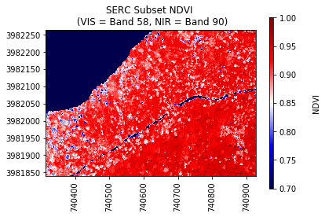

```python
plt.figure(2)
plot_aop_refl(ndvi1,[740315.0, 740928.0, 3981839.0, 3982265.0],
              colorlimit = (0.7,1.0),
              title='SERC Subset NDVI \n (VIS = Band 58, NIR = Band 90)',
              cmap_title='NDVI',
              colormap='seismic')
plt.show()
```

```python
metadata2['ext_dict']
```

```
{'xMax': 740928.0, 'xMin': 740315.0, 'yMax': 3982265.0, 'yMin': 3981839.0}
```

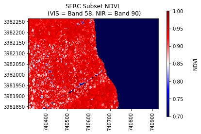

```python
plt.figure(3)
plot_aop_refl(ndvi2,[740315.0, 740928.0, 3981839.0, 3982265.0],
              colorlimit = (0.7,1.0),
              title='SERC Subset NDVI \n (VIS = Band 58, NIR = Band 90)',
              cmap_title='NDVI',
              colormap='seismic')
plt.show()
```

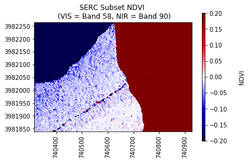

```python
plt.figure(3)
plot_aop_refl(ndvi1-ndvi2,[740315.0, 740928.0, 3981839.0, 3982265.0],
              colorlimit = (-0.2,0.2),
              title='SERC Subset NDVI \n (VIS = Band 58, NIR = Band 90)',
              cmap_title='NDVI',
              colormap='seismic')
plt.show()
```